# tianlin_bios611_P1

Tianlin

9/24/2018

## Project1

### Figure 1: ChickWeight dataset

#### How average weights of chicks vary by diet plan and growth time.

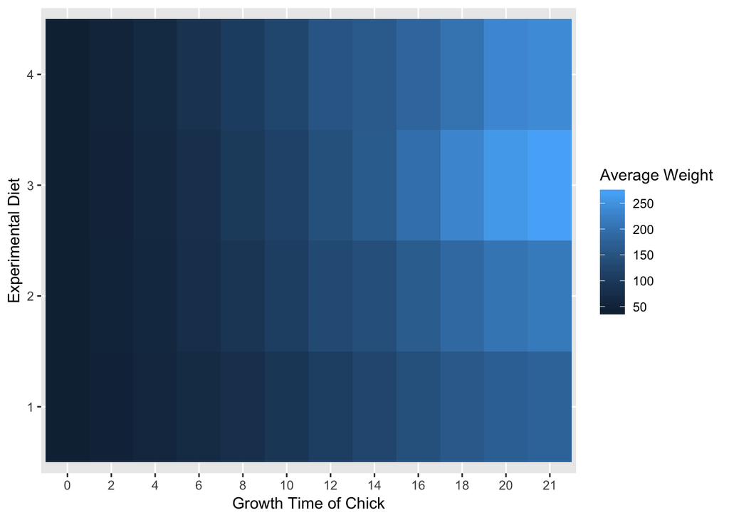

```r
# data preparation: to tibble
cw <- as.tibble(ChickWeight)

# boxplot: x = time, y = weight
cw %>%
  group_by(Time, Diet) %>%
  summarise(weight = mean(weight, na.rm = TRUE)) %>%
  ggplot(aes(x = factor(Time), y = Diet, fill = weight)) +
    geom_tile() +
    labs(x = "Growth Time of Chick", y = "Experimental Diet", fill = "Average Weight")
```

This figure was derived from the “ChickWeight” data set in R, which is the record from an experiment on the effect of diet on early growth of chicks. The body weights of the chicks were measured at birth and every second day thereafter until day 20. There were four groups on chicks on different protein diets. The `average` weights of chicks is 121.8. however, it is the mean of all weights regardless which chick and the growth tome period. So, to use the `mean` in a more accurate way, I must need to group it by `Time` and maybe `Chick`.

From the figure, we can see that the rank from high to low about the effect of diet on early growth of chicks are `Diet3` > `Diet4` > `Diet2` > `Diet1`.

As a next step, it will be interesting to observe the effect of each diet in several certain time period like `0 - 6`, `8 - 10` etc. By find the best diet plan of each period, I may get a best diet plan which is a combination of these 4 diets. For example, in the first 6 days, using diet 1 and then using diet 3.

### Figure 2: Volcano dataset

#### The pattern of topographic value of volcano

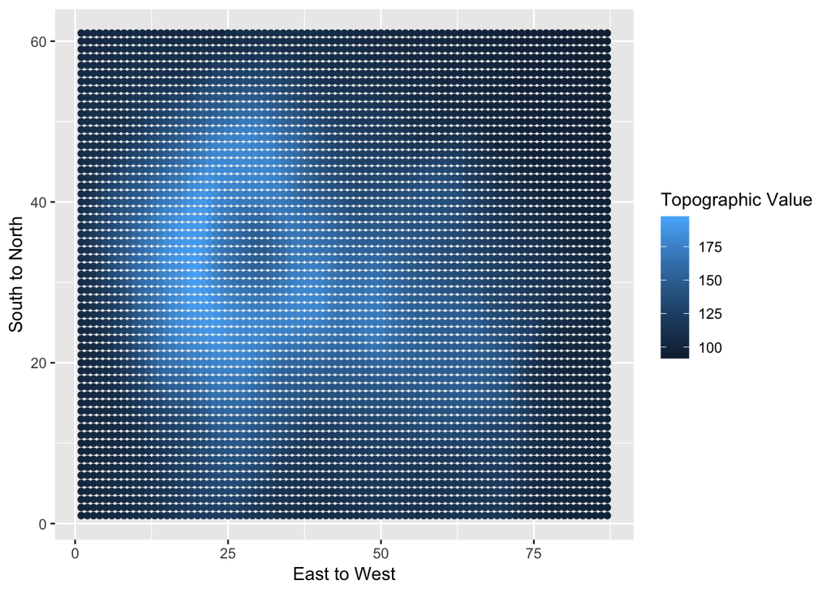

```r
# data preparation: matrix to tibble
vcn <- volcano
colnames(vcn) <- 1:61
rownames(vcn) <- 1:87
vcn <- melt(vcn)
names(vcn) <- c("East to West","South to North","Topographic Value")
vcn <- as.tibble(vcn)

# plot
vcn %>%
  ggplot(mapping = aes(x = `East to West`, y = `South to North`, color = `Topographic Value`)) +
    geom_point(show.legend = TRUE)
```

This figure was derived from the “volcano” data set in R, which is digitized from a topographic map by Ross Ihaka. It is a `matrix` of the “Topographic Information on Auckland’s Maunga Whau Volcano” with rows corresponding to grid lines running east to west and columns to grid lines running south to north. The `average` topographic value of the whole area is 130.2 and the most frequently appeared value is “96” with 159 times.

I used `Scatterplot` here tended to show the value like a map considering that the columns and rows in this dataset represent `East to West` and `South to North`. The pattern of the distribution of topographic values are pretty obvious to some extent:

1. Eastern area has higer values than western area.
2. Seems like there are some circular lines that can be used to show the specific pattern in Eastern area. Etc.

As a next step, first, it would be interesting to add some other functions or adjustments to make the figure more visible like adding some skech lines of thoes potential circular, use different color scales, or define the area more specifically and discover the pattern in each of them maybe. Then, instead of only look at the comparision between western and eastern, I could also detailly inspect one area like find out is there a very compatible and accurate pattern of this area.

### Figure 3: mtcars dataset

#### Cars’ mpg distribution by cyl and the transmission type.

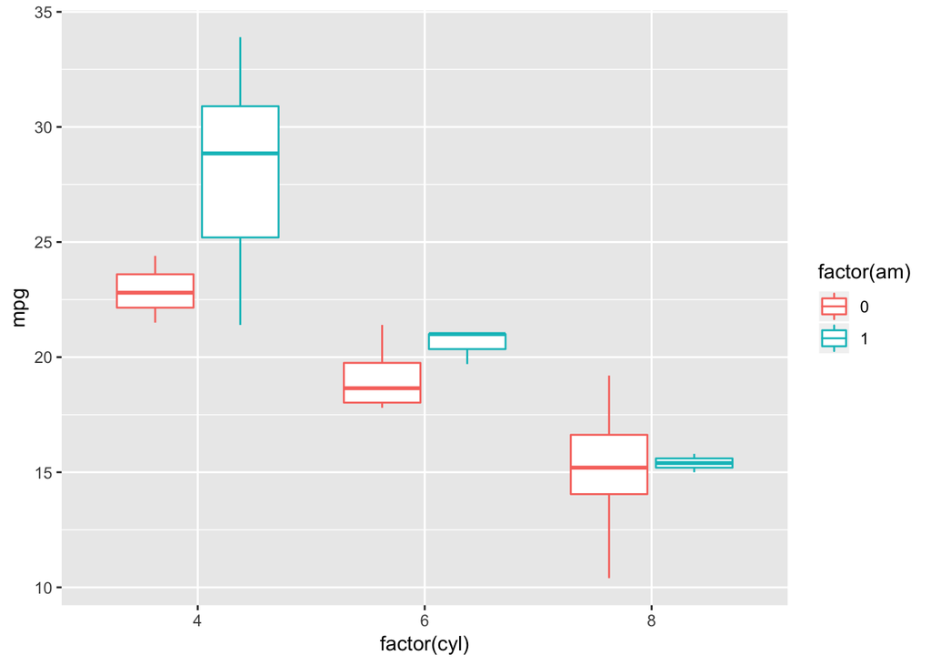

```r
# data preparation: mtcars to tibble
mtc <- as.tibble(mtcars)

# Plot:
mtc %>%
ggplot(aes(factor(cyl), y = mpg, color = factor(am))) +
  geom_boxplot()
```

This figure was derived from the “mtcars” data set in R, which was extracted from the 1974 Motor Trend US magazine, and comprises fuel consumption and 10 aspects of automobile design and performance for 32 automobiles (1973–74 models).

I think for most people who want to buy a car, the `mpg: Miles/(US) gallon` is always a selection factor, and based on my own experience, I think the `cyl: Number of cylinders` alwyas affect the mpg. So, here, I plot the mpg distribution by cyl and the transmission type (Transmission: 0 = automatic, 1 = manual).

We could find that:

1. mpg is negatively related to the number of cyl.
2. manually driven cars have higher mpg.

In the next step, I may filter out all the data of all the automatic transmission cars to analyze in detail.

### Figure 4: iris dataset

#### The relation between `Sepal.Length` and `Sepal.Width` in different `Species` & Possible prediction

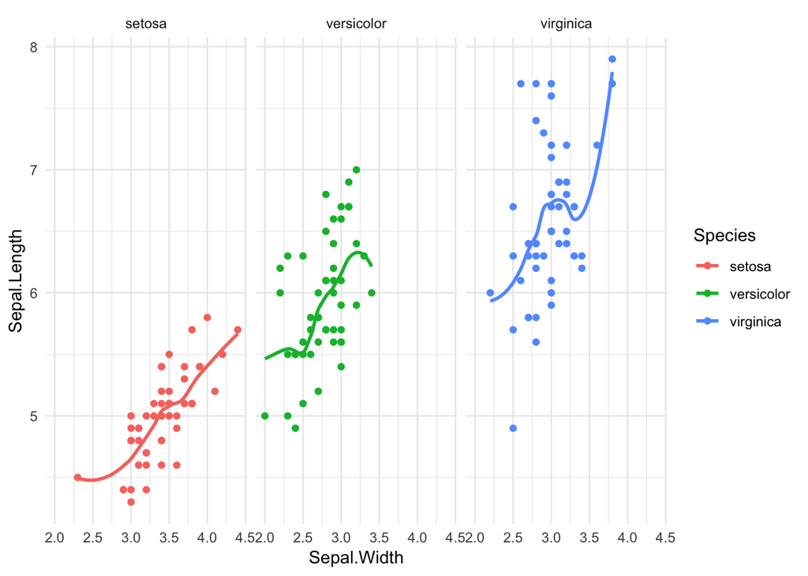

```r
iris %>%
  ggplot(aes(x = Sepal.Width, y = Sepal.Length, color = Species)) +
    geom_point() +
    geom_smooth(se = FALSE) +
    facet_wrap(~Species) +
    theme_minimal()
```

This figure was derived from the “iris” data set in R, which gives the measurements in centimeters of the variables sepal length and width and petal length and width, respectively, for 50 flowers from each of 3 species of iris. Here I want to see the The relation between `Sepal.Length` and `Sepal.Width` in different `Species`.

From the figure, `setosa` seems has a more linearable trend while the other two make me think that there is no certain relationship between length and width.

So, in the next step, I’ll try to find out is other attributes like `Petal.Length` and `Petal.Width` have more significant relationship . Besides, if I don’t use `facet_wrap()` as follows:

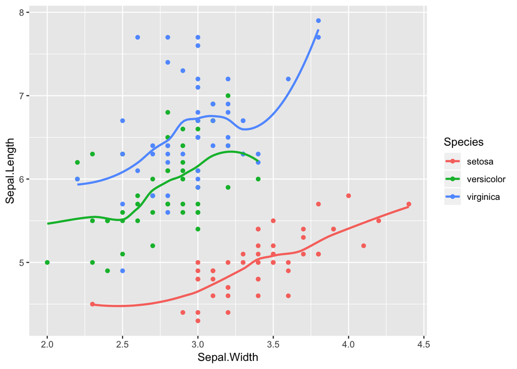

```r
iris %>%
  ggplot(aes(x = Sepal.Width, y = Sepal.Length, color = Species)) +
    geom_point() +
    geom_smooth(se = FALSE)
```

Seems like the distribution of three species have boundaries. So, I think using the for attributes as conditions may successfully predict the species of a new iris.